# Analisis Data Project Kelompok 18 - Praktikum MPDW Pekan 9

## Penanganan Ketidakstasioneran Data

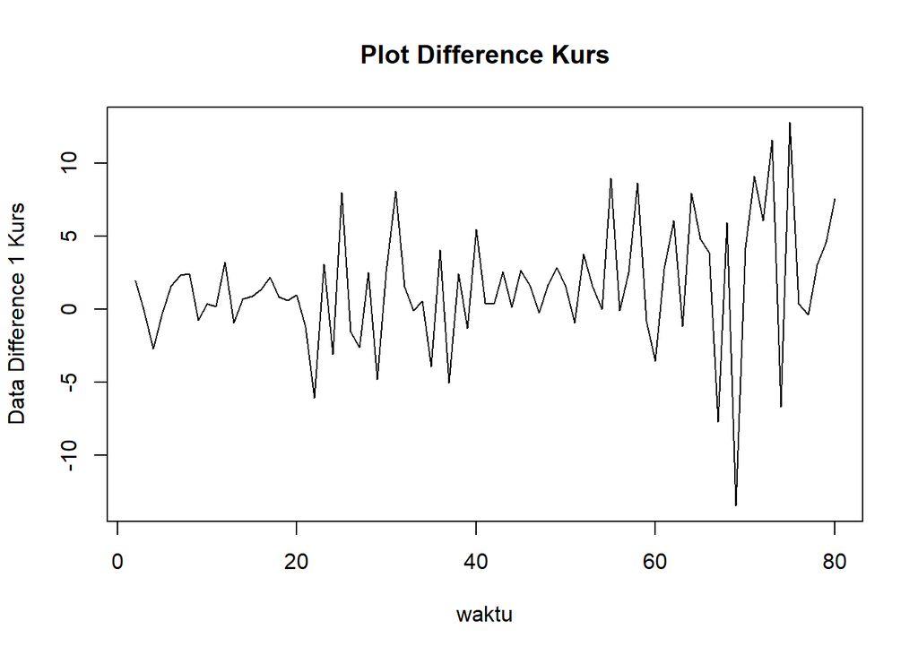

```r
train.diff<-diff(train.ts,differences = 1)
plot.ts(train.diff, lty=1, xlab="waktu", ylab="Data Difference 1 Kurs", main="Plot Difference Kurs")
```

Berdasarkan plot data deret waktu, terlihat bahwa data sudah stasioner dalam rataan ditandai dengan data bergerak pada nilai tengah tertentu (tidak terdapat trend ataupun musiman pada data)

### Plot ACF

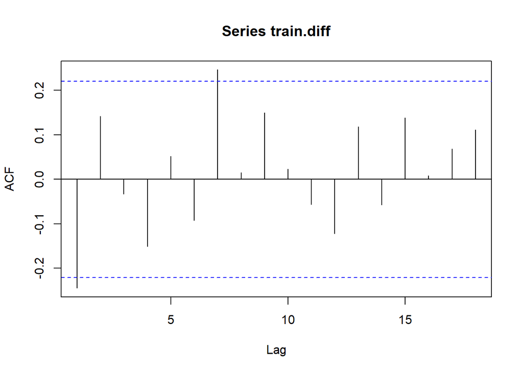

```r
acf(train.diff)
```

Berdasarkan plot tersebut, terlihat bahwa plot ACF cuts off pada lag ke 1. Hal ini menandakan data sudah stasioner dalam rataan dan ketidakstasioneran data telah berhasil tertangani. Akan tetapi plot acf arima (0,1,0) signifikan pada lag ke-7, sehingga sisaan tidak saling bebas. Kondisi ini akan diuji lebih lanjut dengan uji formal.

### Uji ADF

```r
tseries::adf.test(train.diff)
```

```
##
##  Augmented Dickey-Fuller Test
##
## data:  train.diff
## Dickey-Fuller = -5.7083, Lag order = 4, p-value = 0.01
## alternative hypothesis: stationary
```

$H_0$ : Data tidak stasioner dalam rataan

$H_1$ : Data stasioner dalam rataan

Berdasarkan uji ADF tersebut, didapat *p-value* sebesar 0.01 yang lebih kecil dari taraf nyata 5% sehingga tolak $H_0$ atau data stasioner dalam rataan. Hal ini sesuai dengan hasil eksplorasi menggunakan plot time series dan plot ACF, sehingga dalam hal ini ketidakstasioneran data sudah berhasil ditangani dan dapat dilanjutkan ke pemodelan

## Spesifikasi Model

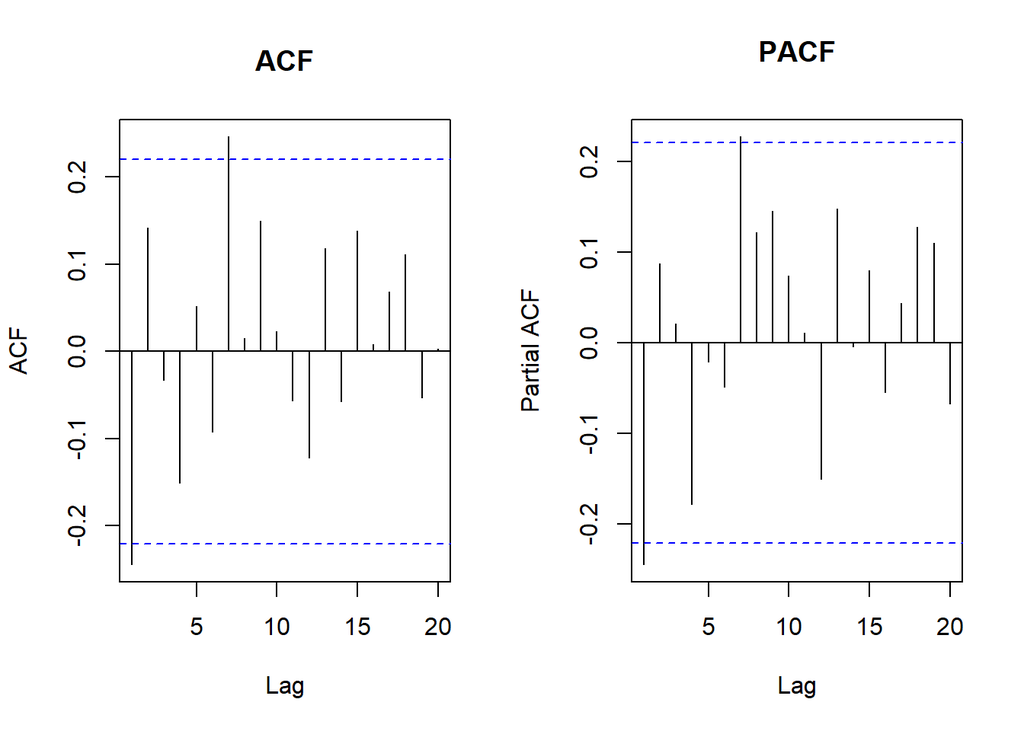

```r
#---SPESIFIKASI MODEL---#
par(mfrow = c(1,2))
acf(train.diff, main="ACF", lag.max=20) #ARIMA(0,1,1)
pacf(train.diff, main="PACF", lag.max=20) #ARIMA(1,1,0)
```

Berdasarkan plot tersebut, terlihat bahwa plot ACF cenderung *cuts off* pada lag ke-1, sehingga jika plot PACF dianggap *tails off*, maka model tentatifnya adalah ARIMA(0,1,1).

Jika baik plot ACF maupun plot PACF keduanya dianggap tails off, maka model yang terbentuk adalah ARIMA(1,1,1).

```r
eacf(train.diff)
```

```
## AR/MA
##   0 1 2 3 4 5 6 7 8 9 10 11 12 13
## 0 x o o o o o x o o o o  o  o  o
## 1 x o o o o o x o o o o  o  o  o
## 2 x o o o o o o o o o o  o  o  o
## 3 o x x o o o o o o o o  o  o  o
## 4 o x x o o o o o o o o  o  o  o
## 5 x o x o o o o o o o o  o  o  o
## 6 o o x o o o o o o o o  o  o  o
## 7 x x o o x x o o o o o  o  o  o
```

```r
#ARIMA(0,1,1) #ARIMA(0,1,2) #ARIMA(1,1,1) #ARIMA(1,1,2)
#Terdapat 5 model tentatif
```

Menggunakan plot EACF, dapat diambil beberapa model dengan melihat ujung segitiga yang terbentuk, antara lain ARIMA(0,1,1), ARIMA(0,1,2), ARIMA(1,1,0), ARIMA(1,1,1), ARIMA(1,1,2).

### Pendugaan Parameter

Selanjutnya akan dilakukan pendugaan parameter kelima model ARIMA yang terbentuk sebelumnya. Pendugaan dilakukan dengan fungsi `Arima()` yang dilanjutkan dengan melihat nilai AIC pada ringkasan data dan melihat signifikansi parameter.

```r
#---PENDUGAAN PARAMETER MODEL---#
model1.data=Arima(train.diff, order=c(0,1,1),method="ML")
summary(model1.data) #AIC=454.41
```

```
## Series: train.diff
## ARIMA(0,1,1)
##
## Coefficients:
##           ma1
##       -0.9543
## s.e.   0.0342
##
## sigma^2 = 18.51:  log likelihood = -225.2
## AIC=454.41   AICc=454.57   BIC=459.12
##
## Training set error measures:
##                     ME     RMSE      MAE  MPE MAPE      MASE      ACF1
## Training set 0.5214103 4.247962 3.039844 -Inf  Inf 0.6267056 -0.301307
```

```r
lmtest::coeftest(model1.data) #seluruh parameter signifikan
```

```
##
## z test of coefficients:
##
##      Estimate Std. Error z value  Pr(>|z|)
## ma1 -0.954283   0.034216  -27.89 < 2.2e-16 ***
## ---
## Signif. codes:  0 '***' 0.001 '**' 0.01 '*' 0.05 '.' 0.1 ' ' 1
```

```r
model2.data=Arima(train.diff, order=c(0,1,2),method="ML")
summary(model2.data) #AIC=450.31
```

```
## Series: train.diff
## ARIMA(0,1,2)
##
## Coefficients:
##           ma1     ma2
##       -1.2224  0.2745
## s.e.   0.1174  0.1130
##
## sigma^2 = 17.29:  log likelihood = -222.15
## AIC=450.31   AICc=450.63   BIC=457.38
##
## Training set error measures:
##                     ME     RMSE      MAE  MPE MAPE      MASE        ACF1
## Training set 0.5774081 4.078111 2.783645 -Inf  Inf 0.5738868 -0.03794176
```

```r
lmtest::coeftest(model2.data) #seluruh parameter signifikan
```

```
##
## z test of coefficients:
##
##     Estimate Std. Error  z value Pr(>|z|)
## ma1 -1.22242    0.11742 -10.4108  < 2e-16 ***
## ma2  0.27451    0.11304   2.4284  0.01517 *
## ---
## Signif. codes:  0 '***' 0.001 '**' 0.01 '*' 0.05 '.' 0.1 ' ' 1
```

```r
model3.data=Arima(train.diff, order=c(1,1,0),method="ML")
summary(model3.data) #AIC=477.77
```

```
## Series: train.diff
## ARIMA(1,1,0)
##
## Coefficients:
##           ar1
##       -0.6511
## s.e.   0.0842
##
## sigma^2 = 25.58:  log likelihood = -236.88
## AIC=477.77   AICc=477.93   BIC=482.48
##
## Training set error measures:
##                      ME     RMSE      MAE  MPE MAPE      MASE       ACF1
## Training set 0.09850548 4.993498 3.730557 -Inf  Inf 0.7691058 -0.2408608
```

```r
lmtest::coeftest(model3.data) #seluruh parameter signifikan
```

```
##
## z test of coefficients:
##
##      Estimate Std. Error z value  Pr(>|z|)
## ar1 -0.651099   0.084182 -7.7344 1.039e-14 ***
## ---
## Signif. codes:  0 '***' 0.001 '**' 0.01 '*' 0.05 '.' 0.1 ' ' 1
```

```r
model4.data=Arima(train.diff, order=c(1,1,1),method="ML")
summary(model4.data) #AIC=449.78
```

```
## Series: train.diff
## ARIMA(1,1,1)
##
## Coefficients:
##           ar1      ma1
##       -0.2941  -0.9327
## s.e.   0.1105   0.0379
##
## sigma^2 = 17.19:  log likelihood = -221.89
## AIC=449.78   AICc=450.11   BIC=456.85
##
## Training set error measures:
##                    ME    RMSE      MAE  MPE MAPE      MASE        ACF1
## Training set 0.560843 4.06615 2.817254 -Inf  Inf 0.5808156 -0.02101514
```

```r
lmtest::coeftest(model4.data) #seluruh parameter signifikan
```

```
##
## z test of coefficients:
##
##      Estimate Std. Error  z value  Pr(>|z|)
## ar1 -0.294092   0.110495  -2.6616  0.007777 **
## ma1 -0.932677   0.037854 -24.6390 < 2.2e-16 ***
## ---
## Signif. codes:  0 '***' 0.001 '**' 0.01 '*' 0.05 '.' 0.1 ' ' 1
```

```r
model5.data=Arima(train.diff, order=c(1,1,2),method="ML")
summary(model5.data) #AIC=451.71
```

```
## Series: train.diff
## ARIMA(1,1,2)
##
## Coefficients:
##           ar1      ma1      ma2
##       -0.3801  -0.8386  -0.0898
## s.e.   0.3168   0.3379   0.3216
##
## sigma^2 = 17.4:  log likelihood = -221.86
## AIC=451.71   AICc=452.26   BIC=461.14
##
## Training set error measures:
##                     ME     RMSE      MAE  MPE MAPE    MASE        ACF1
## Training set 0.5552036 4.064852 2.825327 -Inf  Inf 0.58248 -0.02835833
```

```r
lmtest::coeftest(model5.data) #hanya parameter ma1 yang signifikan
```

```
##
## z test of coefficients:
##
##      Estimate Std. Error z value Pr(>|z|)
## ar1 -0.380084   0.316769 -1.1999  0.23019
## ma1 -0.838614   0.337938 -2.4816  0.01308 *
## ma2 -0.089826   0.321570 -0.2793  0.77999
## ---
## Signif. codes:  0 '***' 0.001 '**' 0.01 '*' 0.05 '.' 0.1 ' ' 1
```

```r
#model yang dipilih adalah model ke-4, yaitu ARIMA(1,1,1)
```

Berdasarkan pendugaan parameter di atas, nilai AIC terkecil dimiliki oleh model ke-4 yaitu model ARIMA(1,1,1) dengan seluruh parameternya signifikan, sehingga model yang dipilih adalah model ARIMA(1,1,1).

### Analisis Sisaan

Model terbaik hasil identifikasi kemudian dicek asumsi sisaannya. Sisaan model ARIMA harus memenuhi asumsi normalitas, kebebasan, dan kehomogenan ragam. Diagnostik model dilakukan secara eksplorasi dan uji formal.

#### Eksplorasi Sisaan

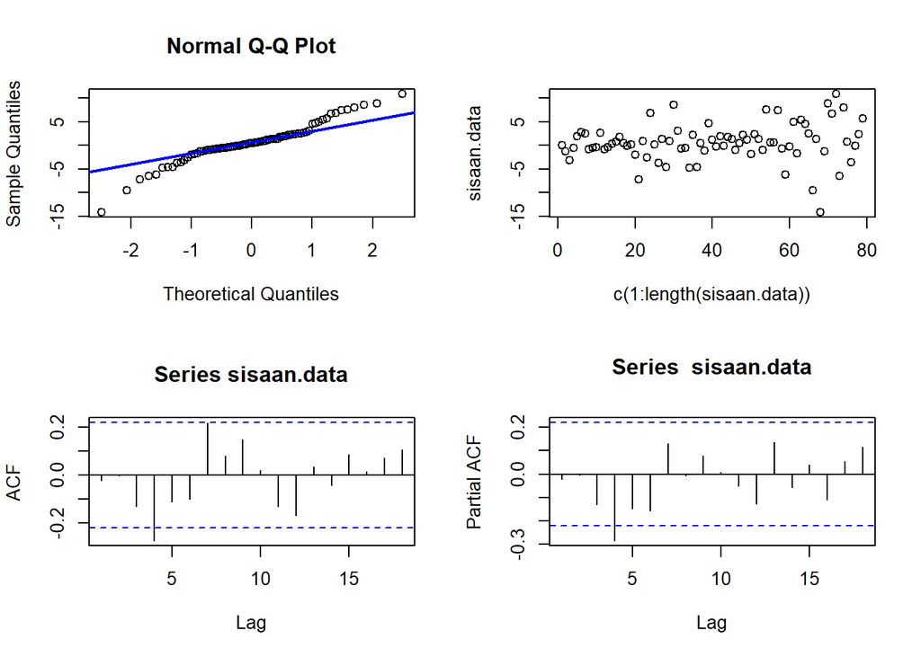

```r
#Eksplorasi
sisaan.data <- model4.data$residuals
par(mfrow=c(2,2))
qqnorm(sisaan.data)
qqline(sisaan.data, col = "blue", lwd = 2)
plot(c(1:length(sisaan.data)),sisaan.data)
acf(sisaan.data)
pacf(sisaan.data)
```

```r
par(mfrow = c(1,1))
```

#### Uji Formal

```r
#1) Sisaan Menyebar Normal
ks.test(sisaan.data,"pnorm")
```

```
##
##  Exact one-sample Kolmogorov-Smirnov test
##
## data:  sisaan.data
## D = 0.28581, p-value = 3.318e-06
## alternative hypothesis: two-sided
```

```r
#tolak H0 > sisaan tidak menyebar normal
```

Selain dengan eksplorasi, asumsi tersebut dapat diuji menggunakan uji formal. Pada tahapan ini uji formal yang digunakan untuk normalitas adalah uji Kolmogorov-Smirnov (KS). Hipotesis pada uji KS adalah sebagai berikut.

$H_0$ : Sisaan menyebar normal

$H_1$ : Sisaan tidak menyebar normal

Berdasarkan uji KS tersebut, didapat *p-value* sebesar 3.318e-06 yang lebih kecil dari taraf nyata 5% sehingga tolak $H_0$ dan menandakan bahwa sisaan tidak menyebar normal. Hal ini sesuai dengan hasil eksplorasi menggunakan plot kuantil-kuantil normal.

```r
#2) Sisaan saling bebas/tidak ada autokorelasi
Box.test(sisaan.data, type = "Ljung")
```

```
##
##  Box-Ljung test
##
## data:  sisaan.data
## X-squared = 0.036231, df = 1, p-value = 0.849
```

```r
#tak tolak H0 > sisaan saling bebas
```

Selanjutnya akan dilakukan uji formal untuk kebebasan sisaan menggunakan uji Ljung-Box. Hipotesis yang digunakan adalah sebagai berikut.

$H_0$ : Sisaan saling bebas

$H_1$ : Sisaan tidak tidak saling bebas

Berdasarkan uji Ljung-Box tersebut, didapat *p-value* sebesar 0.849 yang lebih besar dari taraf nyata 5% sehingga tak tolak $H_0$ dan menandakan bahwa sisaan saling bebas.

```r
#3) Sisaan homogen
Box.test((sisaan.data)^2, type = "Ljung")
```

```
##
##  Box-Ljung test
##
## data:  (sisaan.data)^2
## X-squared = 0.00070768, df = 1, p-value = 0.9788
```

```r
#tak tolak H0 > sisaan homogen
```

Hipotesis yang digunakan untuk uji kehomogenan ragam adalah sebagai berikut.

$H_0$ : Ragam sisaan homogen

$H_1$ : Ragam sisaan tidak homogen

Berdasarkan uji Ljung-Box terhadap sisaan kuadrat tersebut, didapat *p-value* sebesar 0.9788 yang lebih besar dari taraf nyata 5% sehingga tak tolak $H_0$ dan menandakan bahwa ragam sisaan homogen.

```r
#4) Nilai tengah sisaan sama dengan nol
t.test(sisaan.data, mu = 0, conf.level = 0.95)
```

```
##
##  One Sample t-test
##
## data:  sisaan.data
## t = 1.2299, df = 78, p-value = 0.2224
## alternative hypothesis: true mean is not equal to 0
## 95 percent confidence interval:
##  -0.3469838  1.4686698
## sample estimates:
## mean of x
##  0.560843
```

```r
#tak tolak h0 > nilai tengah sisaan sama dengan 0
```

Terakhir, dengan uji-t, akan dicek apakah nilai tengah sisaan sama dengan nol. Hipotesis yang diujikan sebagai berikut.

$H_0$ : nilai tengah sisaan sama dengan 0

$H_1$ : nilai tengah sisaan tidak sama dengan 0

Berdasarkan uji-t tersebut, didapat *p-value* sebesar 0.2224 yang lebih besar dari taraf nyata 5% sehingga tak tolak $H_0$ dan menandakan bahwa nilai tengah sisaan sama dengan nol.

### Overfitting

Tahapan selanjutnya adalah *overfitting* dilakukan dengan menaikkan orde AR(p) dan MA(q) dari model ARIMA(1,1,1) untuk melihat apakah terdapat model lain yang lebih baik dari model saat ini. Kandidat model *overfitting* adalah ARIMA(2,1,1) dan ARIMA(1,1,2).

```r
#---OVERFITTING---#
model4a.data=Arima(data.train, order=c(2,1,1),method="ML")
summary(model4a.data) #455.85
```

```
## Series: data.train
## ARIMA(2,1,1)
##
## Coefficients:
##          ar1     ar2      ma1
##       0.7024  0.2902  -0.9347
## s.e.  0.1113  0.1102   0.0402
##
## sigma^2 = 17.35:  log likelihood = -223.92
## AIC=455.85   AICc=456.39   BIC=465.33
##
## Training set error measures:
##                     ME     RMSE     MAE       MPE    MAPE      MASE        ACF1
## Training set 0.7339762 4.059427 2.80433 0.7560416 4.06176 0.8596898 -0.02432715
```

```r
lmtest::coeftest(model4a.data) #seluruh parameter signifikan
```

```
##
## z test of coefficients:
##
##      Estimate Std. Error  z value  Pr(>|z|)
## ar1  0.702357   0.111295   6.3108 2.776e-10 ***
## ar2  0.290214   0.110178   2.6341  0.008437 **
## ma1 -0.934736   0.040197 -23.2537 < 2.2e-16 ***
## ---
## Signif. codes:  0 '***' 0.001 '**' 0.01 '*' 0.05 '.' 0.1 ' ' 1
```

```r
model4b.data=Arima(data.train, order=c(1,1,2),method="ML")
summary(model4b.data) #463
```

```
## Series: data.train
## ARIMA(1,1,2)
##
## Coefficients:
##          ar1      ma1     ma2
##       0.1511  -0.2570  0.3008
## s.e.  0.3299   0.3127  0.1203
##
## sigma^2 = 19.26:  log likelihood = -227.5
## AIC=463   AICc=463.54   BIC=472.47
##
## Training set error measures:
##                   ME     RMSE      MAE      MPE     MAPE      MASE        ACF1
## Training set 1.24518 4.277263 3.130999 1.438523 4.474641 0.9598327 -0.08489183
```

```r
lmtest::coeftest(model4b.data) #hanya signifikan pada parameter ma2
```

```
##
## z test of coefficients:
##
##     Estimate Std. Error z value Pr(>|z|)
## ar1  0.15105    0.32992  0.4579  0.64706
## ma1 -0.25698    0.31274 -0.8217  0.41124
## ma2  0.30085    0.12025  2.5018  0.01236 *
## ---
## Signif. codes:  0 '***' 0.001 '**' 0.01 '*' 0.05 '.' 0.1 ' ' 1
```

```r
#model yang dipilih adalah model awal, yaitu ARIMA(1,1,1)
```

Berdasarkan kedua model hasil *overfitting* di atas, model ARIMA(2,1,1) dan ARIMA(1,1,2) memiliki AIC yang lebih besar dibandingkan dengan model ARIMA(1,1,1), selain itu parameter khususnya pada model ARIMA(1,1,2) tidak seluruhnya signifikan. Oleh karena itu, model ARIMA(1,1,1) akan tetap digunakan untuk melakukan peramalan.

### Peramalan

Peramalan dilakukan menggunakan fungsi `forecast()` . Contoh peramalan berikut ini dilakukan untuk 40 bulan ke depan.

```r
#---FORECAST---#
ramalan <- forecast::forecast(model4.data, h = 40)
ramalan
```

```
##     Point Forecast     Lo 80    Hi 80     Lo 95     Hi 95
##  81       1.445271 -3.867569 6.758110 -6.680016  9.570557
##  82       3.240621 -2.207107 8.688348 -5.090959 11.572200
##  83       2.712623 -2.781435 8.206681 -5.689814 11.115060
##  84       2.867903 -2.628156 8.363962 -5.537594 11.273399
##  85       2.822236 -2.682789 8.327261 -5.596973 11.241446
##  86       2.835667 -2.675748 8.347081 -5.593315 11.264648
##  87       2.831717 -2.686788 8.350222 -5.608108 11.271542
##  88       2.832878 -2.692496 8.358252 -5.617452 11.283209
##  89       2.832537 -2.699760 8.364834 -5.628381 11.293455
##  90       2.832637 -2.706555 8.371830 -5.638827 11.304101
##  91       2.832608 -2.713477 8.378693 -5.649398 11.314613
##  92       2.832616 -2.720351 8.385584 -5.659915 11.325147
##  93       2.832614 -2.727228 8.392456 -5.670431 11.335658
##  94       2.832615 -2.734093 8.399322 -5.680930 11.346159
```

[output cut: 26 more lines]

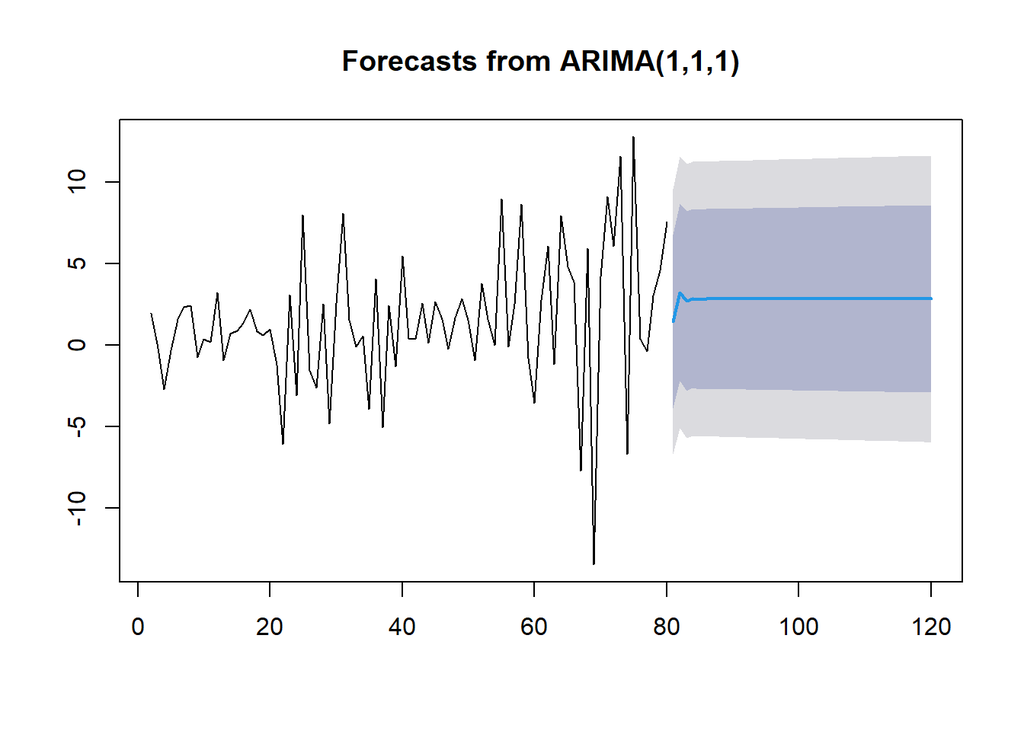

```r
data.ramalan <- ramalan$mean
plot(ramalan)
```

Berdasarkan hasil plot ramalan di atas, dapat dilihat bahwa ramalan ARIMA(1,1,1) cenderung stabil hingga akhir periode. Selanjutnya, dapat dicari nilai akurasi antara hasil ramalan dengan data uji sebagai berikut.

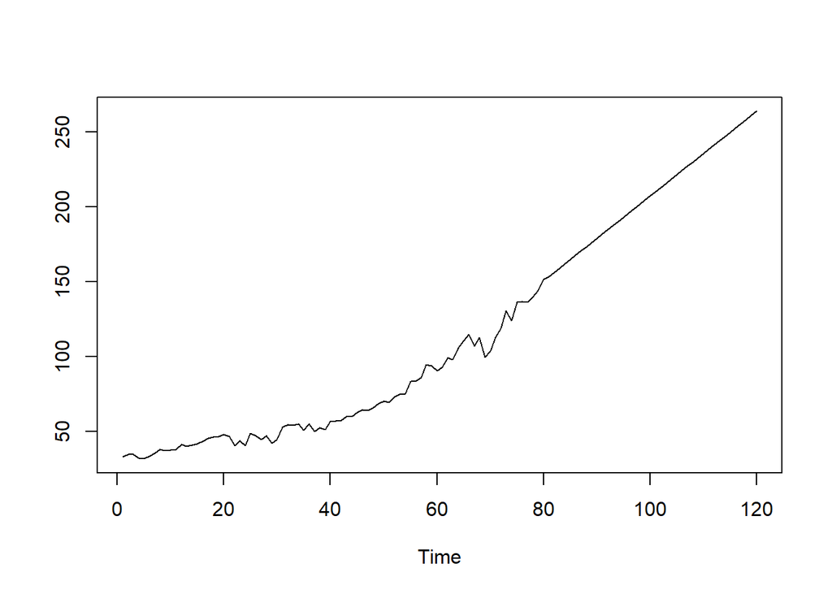

```r
pt_1 <- train.ts[80] #nilai akhir data latih
hasil.forc.Diff <- data.ramalan
hasil <- diffinv(hasil.forc.Diff, differences = 1) + pt_1
#hasil sama hasilnya dengan: cumsum(c(pt_1,hasil.forc.Diff))
ts.plot(train.ts,hasil)
```

```r
perbandingan.da<-matrix(data=c(head(test.ts, n=40), hasil[-1]),
                     nrow = 40, ncol = 2)
colnames(perbandingan.da)<-c("Aktual","Hasil Forecast")
perbandingan.da
```

```
##       Aktual Hasil Forecast
##  [1,] 158.78       153.2553
##  [2,] 170.43       156.4959
##  [3,] 165.31       159.2085
##  [4,] 153.00       162.0764
##  [5,] 175.80       164.8987
##  [6,] 182.54       167.7343
##  [7,] 203.14       170.5660
##  [8,] 211.52       173.3989
##  [9,] 225.51       176.2315
## [10,] 213.49       179.0641
## [11,] 204.29       181.8967
## [12,] 214.51       184.7293
## [13,] 222.53       187.5619
## [14,] 235.06       190.3945
```

[output cut: 26 more lines]

```r
accuracy(ts(hasil[-1]), head(test.ts,n=40))
```

```
##                ME     RMSE      MAE      MPE     MAPE      ACF1 Theil's U
## Test set 38.00255 52.26574 41.46678 13.97464 15.51804 0.8785101  2.714657
```